# IE582 HOMEWORK 2

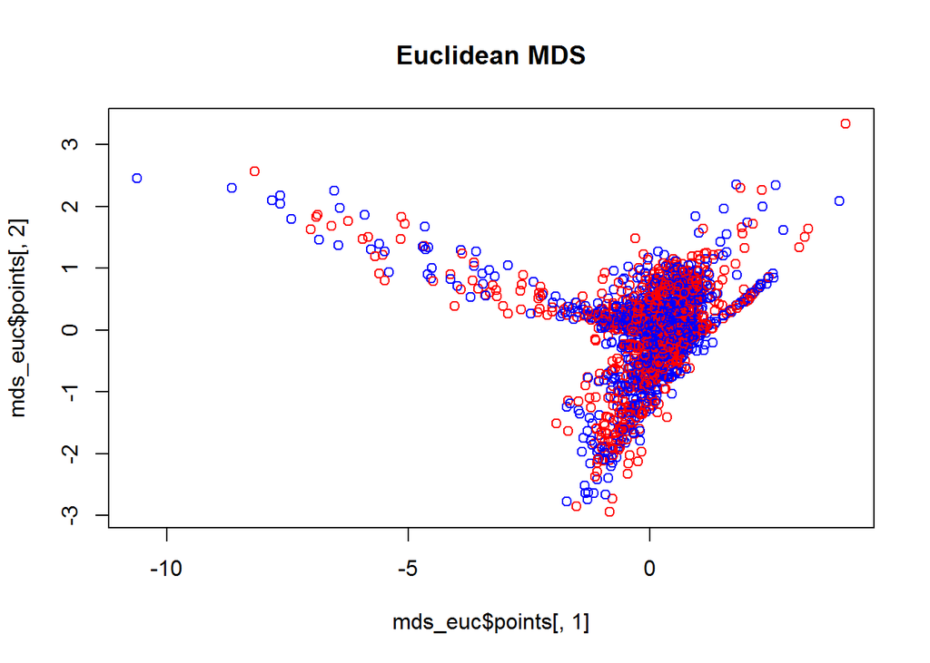

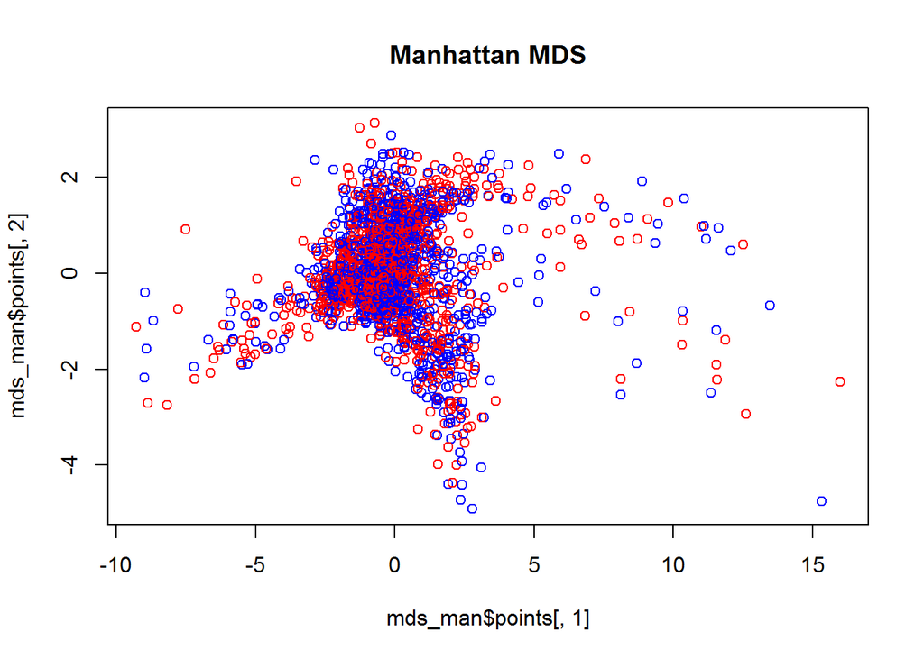

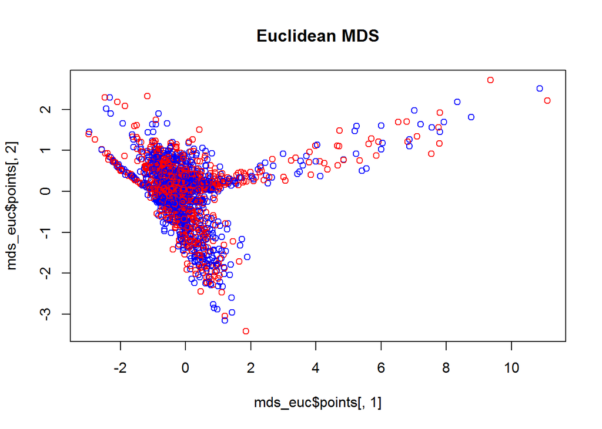

```
## Error in is.data.table(y): 'sbobet_wide' nesnesi bulunamadı
```

[figure not shown]

[figure not shown]

# **Task 2**

The same process in Task 1 Part a is repeated to check the effects of the odds on match outcomes as Tie, Home and Away.

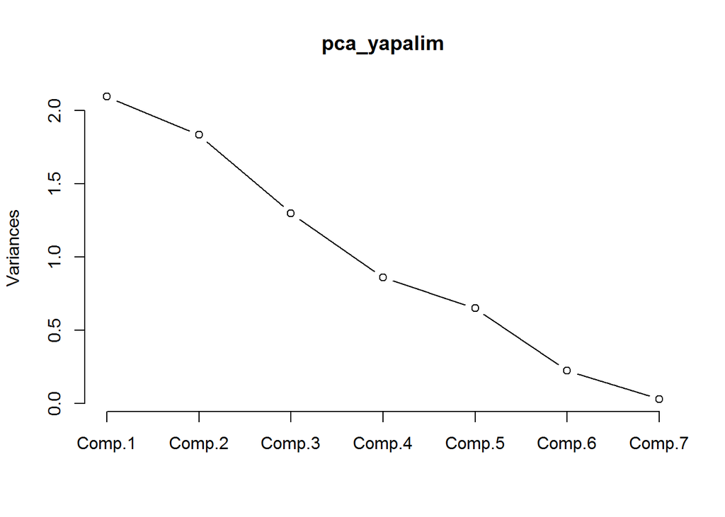

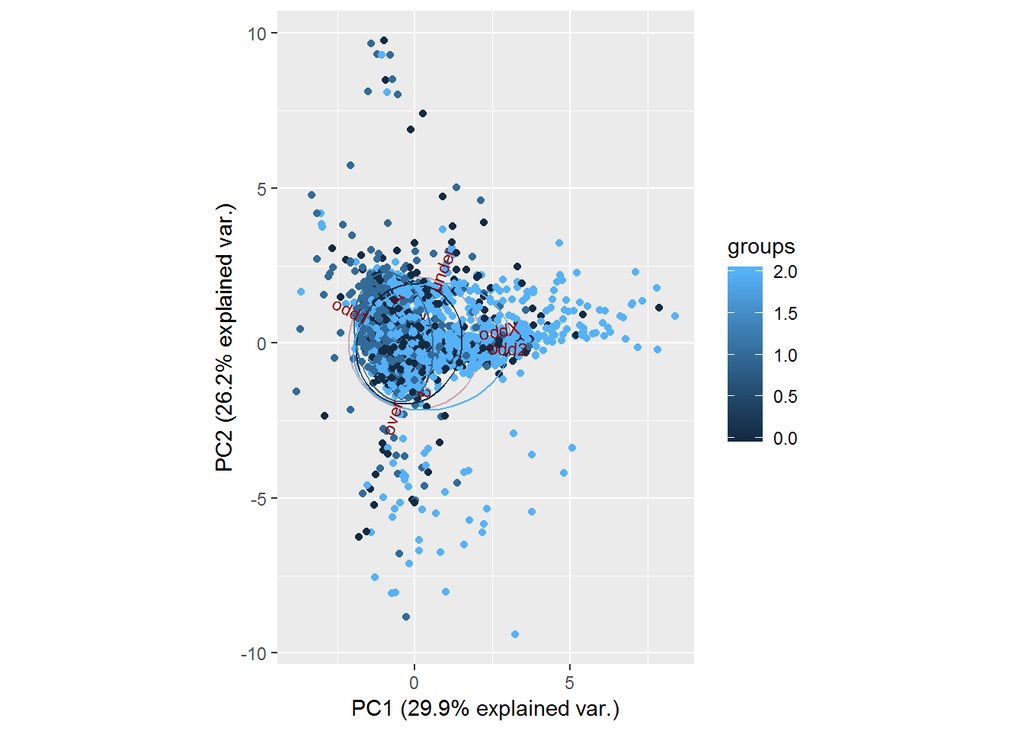

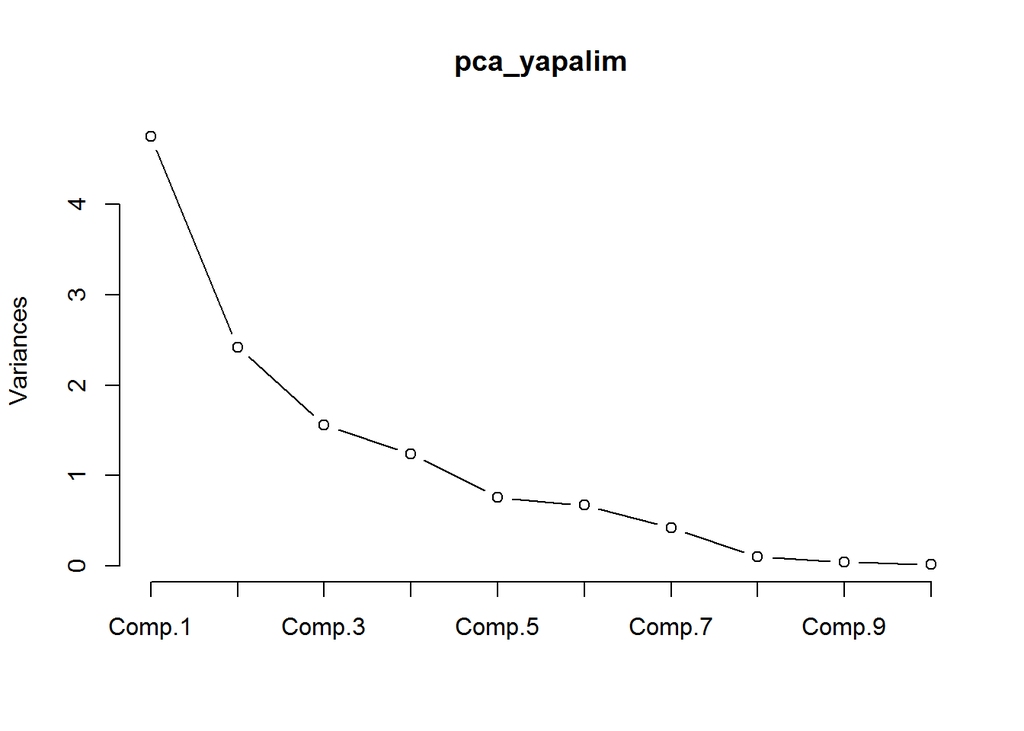

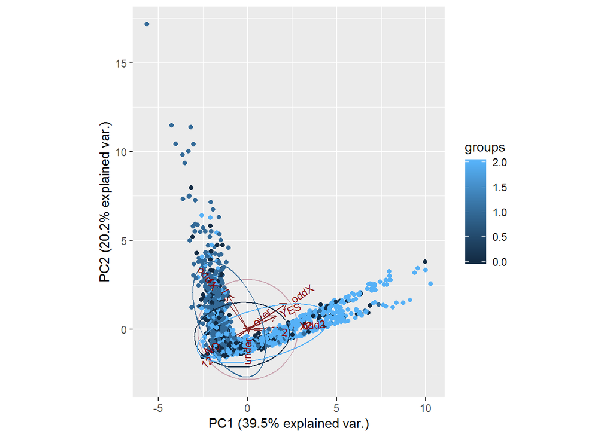

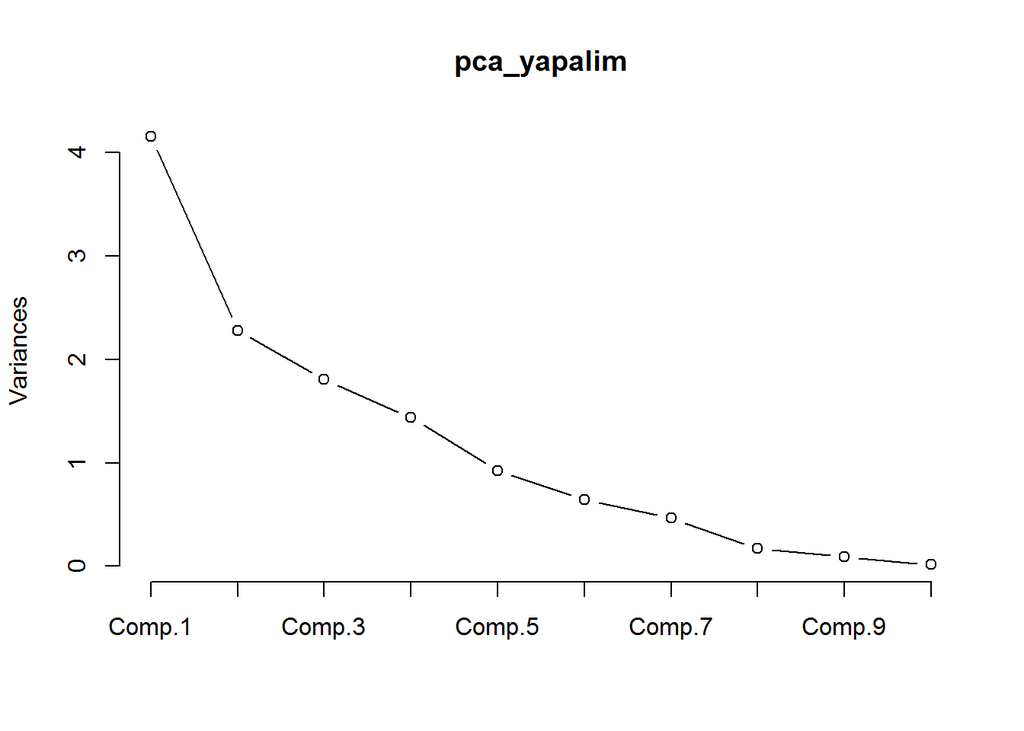

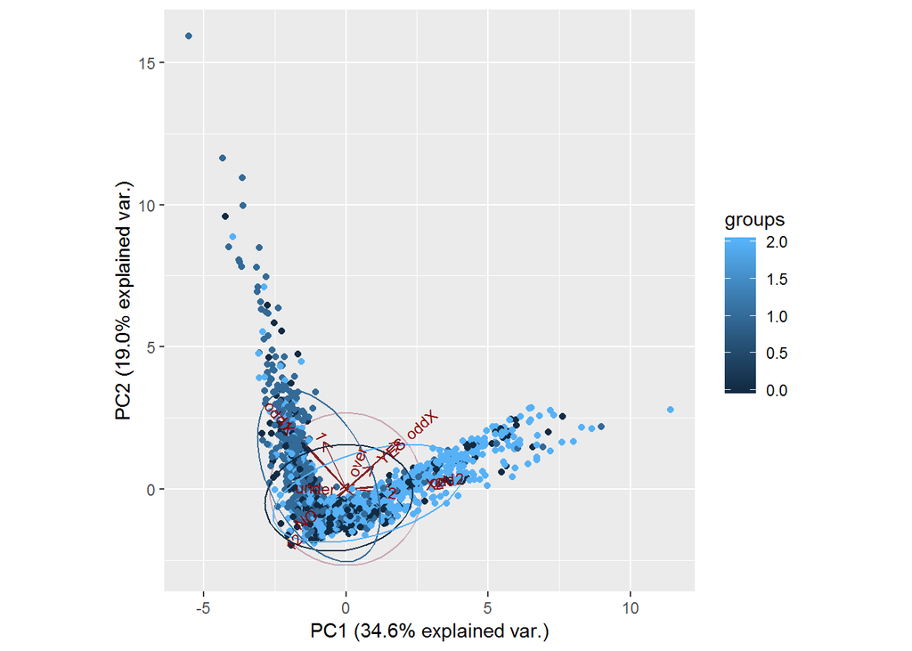

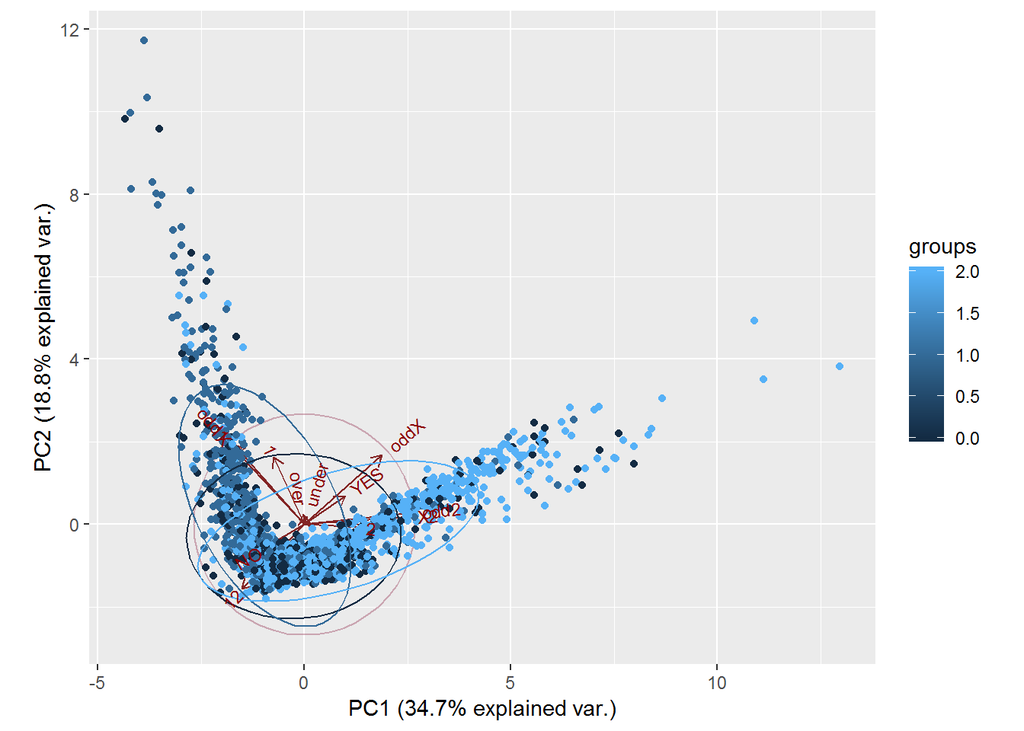

[output not shown]

[output not shown]

# **Task 3**

Firstly, the image of 200x200 size is displayed and then each channel of it is displayed.

```
## [1] 200 200   3
```

[figure not shown]

[figure not shown]

Then, in order to create a noisy image, add a random noise from uniform distribution between 0 and 0.1 to each pixel value for each channel of original image.

[figure not shown]

Then each channel with noise is displayed.

[figure not shown]

Now, we can convert the image to grayscale one.

[figure not shown]

Now, we can extract the patches which have sizes 3 by 3.

```r
#extract patches

patches<-list(NULL)
a=0
for(i in c(1:198)){for(j in c(1:198)){
  vector_patches<-c(((t(graywinnie[c(i:(i+2)),c(j:(j+2))]))))
 a<-a+1
  patches[[a]] <- vector_patches
}}

patches <-t(as.data.table(patches[]))
```

# **A.**

We apply PCA to the matrix of the grayscaled image.

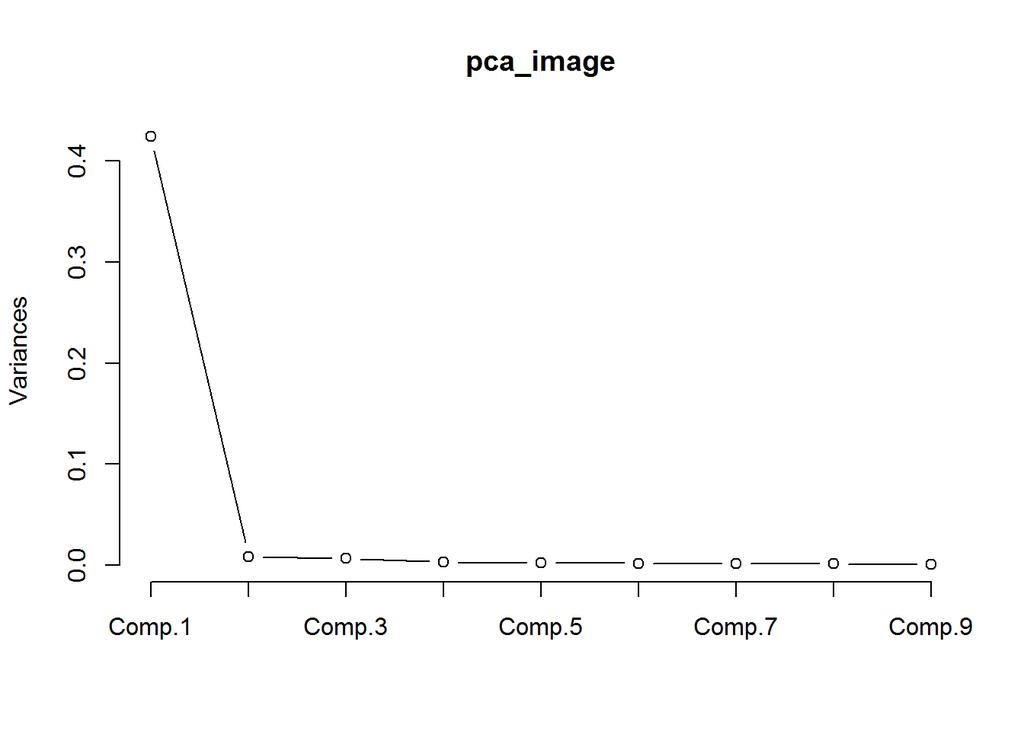

# **B.**

[figure not shown]

# **Appendix**

R codes with necessary explanations

```r
require(data.table)
require(anytime)
require(dplyr)
library(ggplot2)
install.packages("dplyr")
install.packages("anytime")
library(RColorBrewer)
library(jpeg)
install.packages("jpeg")
library(grid)
library(gridExtra)
install.packages("ggplot2")

install.packages("scales")
library(scales)
library(devtools)
library(devtools)
install_github("vqv/ggbiplot")
library(ggbiplot)
#task 1 part a#

matches_file_path='C:/Users/casper/Downloads/df9b1196-e3cf-4cc7-9159-f236fe738215_matches.rds'

odd_details_file_path='C:/Users/casper/Downloads/df9b1196-e3cf-4cc7-9159-f236fe738215_odd_details.rds'
matches=readRDS(matches_file_path)
odds=readRDS(odd_details_file_path)
str(matches)
matches=unique(matches)

#transform unix time to date time
matches[,match_time:=anytime(date)]


matches[,c("HomeGoals","AwayGoals"):=tstrsplit(score,':')]


#transform characters to numeric for scores
matches$HomeGoals=as.numeric(matches$HomeGoals)
matches[,AwayGoals:=as.numeric(AwayGoals)]

#calculate total goals
matches[,TotalGoals:=HomeGoals+AwayGoals]

# mark over under
matches[,IsOver:=0]
matches[TotalGoals>2.5,IsOver:=1]

#mark match outcome#
matches[,Result:=0]

matches[matches$AwayGoals>matches$HomeGoals,Result:=1]
matches[matches$AwayGoals<matches$HomeGoals,Result:=2]



#order data in ascending date
odds_ordered=odds[order(matchId,oddtype,bookmaker,date)]


odds_ordered_final=odds_ordered[,list(final_odd=odd[.N]),
                                      by=list(matchId,oddtype,bookmaker)]

#get pinnacle final over under odds
pinnacle_odds=odds_ordered_final[bookmaker=='Pinnacle' ]

pinnacle_wide=dcast(pinnacle_odds,
                    matchId~oddtype,
                    value.var='final_odd')
merged_matches=merge(matches,pinnacle_wide,by='matchId')



merged_matches=merged_matches[complete.cases(merged_matches)]

merged_matches[,c("Year","Month","Weekday","Hour"):=NULL]

resulting<-as.numeric(merged_matches$IsOver)
pca_yapalim<-princomp(merged_matches[,c(14:20)],cor=TRUE)
summary(pca_yapalim)
biplot(pca_yapalim)
plot(pca_yapalim,type="lines")
str(pca_yapalim)
pca_yapalim
pca_yapalim$loadings
Comp1 <- pca_yapalim$scores[,1]
Comp2<- pca_yapalim$scores[,2]


#başka bir boyama denemesi#
col=ifelse(merged_matches[,IsOver]==0, "red","blue")

#aşağısı yok#
color=rep(NA,length=length(merged_matches$IsOver))
color[which(merged_matches$IsOver==0)]= "red"
color[which(merged_matches$IsOver==1)]="blue"
merged_matches$IsOver=as.factor(merged_matches$IsOver)
color_easy=c("red","blue")[merged_matches$IsOver]
plot(Comp1,Comp2, col=color_easy,pch=25 ) #bilemedim#
legend("topleft",paste("IsOver",levels(merged_matches$IsOver)),col=unique(color_easy),pch=25)
#yukarısı yok#
print(ggbiplot(pca_yapalim, obs.scale = 1, var.scale = 1, groups = resulting, ellipse = TRUE, circle = TRUE))

#get BetVictor final over under odds
betvictor_odds=odds_ordered_final[bookmaker=='BetVictor' ]

betvictor_wide=dcast(betvictor_odds,
                    matchId~oddtype,
                    value.var='final_odd')
merged_matches=merge(matches,betvictor_wide,by='matchId')



merged_matches=merged_matches[complete.cases(merged_matches)]


resulting<-as.numeric(merged_matches$IsOver)
pca_yapalim<-princomp(merged_matches[,c(14:25)],cor=TRUE)
summary(pca_yapalim)
pca_yapalim$loadings
biplot(pca_yapalim)
plot(pca_yapalim,type="lines")
str(pca_yapalim)
print(ggbiplot(pca_yapalim, obs.scale = 1, var.scale = 1, groups = resulting, ellipse = TRUE, circle = TRUE))
#get ComeOn final over under odds
comeon_odds=odds_ordered_final[bookmaker=='ComeOn' ]

comeon_wide=dcast(comeon_odds,
                     matchId~oddtype,
                     value.var='final_odd')
merged_matches=merge(matches,comeon_wide,by='matchId')



merged_matches=merged_matches[complete.cases(merged_matches)]



resulting<-as.numeric(merged_matches$IsOver)
pca_yapalim<-princomp(merged_matches[,c(14:25)],cor=TRUE)
summary(pca_yapalim)
biplot(pca_yapalim)
plot(pca_yapalim,type="lines")
str(pca_yapalim)
print(ggbiplot(pca_yapalim, obs.scale = 1, var.scale = 1, groups = resulting, ellipse = TRUE, circle = TRUE))
pca_yapalim$loadings
#get 10Bet final over under odds
tenbet_odds=odds_ordered_final[bookmaker=='10Bet' ]

tenbet_wide=dcast(tenbet_odds,
                  matchId~oddtype,
                  value.var='final_odd')
merged_matches=merge(matches,tenbet_wide,by='matchId')



merged_matches=merged_matches[complete.cases(merged_matches)]


resulting<-as.numeric(merged_matches$IsOver)
pca_yapalim<-princomp(merged_matches[,c(14:25)],cor=TRUE)
summary(pca_yapalim)
biplot(pca_yapalim)
plot(pca_yapalim,type="lines")
str(pca_yapalim)
print(ggbiplot(pca_yapalim, obs.scale = 1, var.scale = 1, groups = resulting, ellipse = TRUE, circle = TRUE))
pca_yapalim$loadings
#get SBOBET final over under odds
sbobet_odds=odds_ordered_final[bookmaker=='SBOBET' ]

sbobettenbet_wide=dcast(sbobet_odds,
                  matchId~oddtype,
                  value.var='final_odd')
merged_matches=merge(matches,sbobet_wide,by='matchId')



merged_matches=merged_matches[complete.cases(merged_matches)]



resulting<-as.numeric(merged_matches$IsOver)
pca_yapalim<-princomp(merged_matches[,c(14:25)],cor=TRUE)
summary(pca_yapalim)
biplot(pca_yapalim)
plot(pca_yapalim,type="lines")
str(pca_yapalim)
print(ggbiplot(pca_yapalim, obs.scale = 1, var.scale = 1, groups = resulting, ellipse = TRUE, circle = TRUE))
pca_yapalim$loadings
#b'ye bakayım biraz#
pinnacle_odds=odds_ordered_final[bookmaker=='Pinnacle' ]

pinnacle_wide=dcast(pinnacle_odds,
                    matchId~oddtype,
                    value.var='final_odd')
merged_matches=merge(matches,pinnacle_wide,by='matchId')



merged_matches=merged_matches[complete.cases(merged_matches)]

merged_matches$IsOver=as.factor(merged_matches$IsOver)
color_easy=c("red","blue")[merged_matches$IsOver]
tomatrix<-data.matrix(merged_matches[,14:20])
tomatrix
distmatManhattan<-dist(tomatrix, method = "manhattan", diag=TRUE, upper=TRUE)
mds_man<-cmdscale(distmatManhattan, eig = TRUE)
mds_man
plot(mds_man$points[,1],mds_man$points[,2],main="Manhattan MDS",col=unique(color_easy))
distmatEuclidean<-dist(tomatrix,method = "euclidean", diag = TRUE, upper = TRUE)
mds_euc<-cmdscale(distmatEuclidean, eig = TRUE)
mds_euc
plot(mds_euc$points[,1],mds_euc$points[,2],main = "Euclidean MDS", col=unique(color_easy))
#get BetVictor final over under odds
betvictor_odds=odds_ordered_final[bookmaker=='BetVictor' ]
```

```r
betvictor_wide=dcast(betvictor_odds,
                     matchId~oddtype,
                     value.var='final_odd')
merged_matches=merge(matches,betvictor_wide,by='matchId')



merged_matches=merged_matches[complete.cases(merged_matches)]
merged_matches$IsOver=as.factor(merged_matches$IsOver)
color_easy=c("red","blue")[merged_matches$IsOver]
tomatrix<-data.matrix(merged_matches[,14:20])
tomatrix
distmatManhattan<-dist(tomatrix, method = "manhattan", diag=TRUE, upper=TRUE)
mds_man<-cmdscale(distmatManhattan, eig = TRUE)
mds_man
plot(mds_man$points[,1],mds_man$points[,2],main="Manhattan MDS",col=unique(color_easy))

distmatEuclidean<-dist(tomatrix,method = "euclidean", diag = TRUE, upper = TRUE)
mds_euc<-cmdscale(distmatEuclidean, eig = TRUE)
mds_euc
plot(mds_euc$points[,1],mds_euc$points[,2],main = "Euclidean MDS", col=unique(color_easy))
#get ComeOn final over under odds
comeon_odds=odds_ordered_final[bookmaker=='ComeOn' ]

comeon_wide=dcast(comeon_odds,
                  matchId~oddtype,
                  value.var='final_odd')
merged_matches=merge(matches,comeon_wide,by='matchId')



merged_matches=merged_matches[complete.cases(merged_matches)]
merged_matches$IsOver=as.factor(merged_matches$IsOver)
color_easy=c("red","blue")[merged_matches$IsOver]
tomatrix<-data.matrix(merged_matches[,14:20])
tomatrix
distmatManhattan<-dist(tomatrix, method = "manhattan", diag=TRUE, upper=TRUE)
mds_man<-cmdscale(distmatManhattan, eig = TRUE)
mds_man
plot(mds_man$points[,1],mds_man$points[,2],main="Manhattan MDS",col=unique(color_easy))
distmatEuclidean<-dist(tomatrix,method = "euclidean", diag = TRUE, upper = TRUE)
mds_euc<-cmdscale(distmatEuclidean, eig = TRUE)
mds_euc
plot(mds_euc$points[,1],mds_euc$points[,2],main = "Euclidean MDS", col=unique(color_easy))
#get 10Bet final over under odds
tenbet_odds=odds_ordered_final[bookmaker=='10Bet' ]

tenbet_wide=dcast(tenbet_odds,
                  matchId~oddtype,
                  value.var='final_odd')
merged_matches=merge(matches,tenbet_wide,by='matchId')

merged_matches=merged_matches[complete.cases(merged_matches)]
merged_matches$IsOver=as.factor(merged_matches$IsOver)
color_easy=c("red","blue")[merged_matches$IsOver]
tomatrix<-data.matrix(merged_matches[,14:20])
tomatrix
distmatManhattan<-dist(tomatrix, method = "manhattan", diag=TRUE, upper=TRUE)
mds_man<-cmdscale(distmatManhattan, eig = TRUE)
mds_man
plot(mds_man$points[,1],mds_man$points[,2],main="Manhattan MDS",col=unique(color_easy))
distmatEuclidean<-dist(tomatrix,method = "euclidean", diag = TRUE, upper = TRUE)
mds_euc<-cmdscale(distmatEuclidean, eig = TRUE)
mds_euc
plot(mds_euc$points[,1],mds_euc$points[,2],main = "Euclidean MDS", col=unique(color_easy))
#get SBOBET final over under odds
sbobet_odds=odds_ordered_final[bookmaker=='SBOBET' ]

sbobettenbet_wide=dcast(sbobet_odds,
                        matchId~oddtype,
                        value.var='final_odd')
merged_matches=merge(matches,sbobet_wide,by='matchId')



merged_matches=merged_matches[complete.cases(merged_matches)]
merged_matches$IsOver=as.factor(merged_matches$IsOver)
color_easy=c("red","blue")[merged_matches$IsOver]
tomatrix<-data.matrix(merged_matches[,14:20])
tomatrix
distmatManhattan<-dist(tomatrix, method = "manhattan", diag=TRUE, upper=TRUE)
mds_man<-cmdscale(distmatManhattan, eig = TRUE)
mds_man
plot(mds_man$points[,1],mds_man$points[,2],main="Manhattan MDS",col=unique(color_easy))
distmatEuclidean<-dist(tomatrix,method = "euclidean", diag = TRUE, upper = TRUE)
mds_euc<-cmdscale(distmatEuclidean, eig = TRUE)
mds_euc
plot(mds_euc$points[,1],mds_euc$points[,2],main = "Euclidean MDS", col=unique(color_easy))


#Task 2#
#get pinnacle final over under odds
pinnacle_odds=odds_ordered_final[bookmaker=='Pinnacle' ]

pinnacle_wide=dcast(pinnacle_odds,
                    matchId~oddtype,
                    value.var='final_odd')
merged_matches=merge(matches,pinnacle_wide,by='matchId')



merged_matches=merged_matches[complete.cases(merged_matches)]



resulting<-as.numeric(merged_matches$IsOver)
pca_yapalim<-princomp(merged_matches[,c(14:20)],cor = TRUE)
pca_yapalim$loadings
summary(pca_yapalim)
biplot(pca_yapalim)
plot(pca_yapalim,type="lines")
resultother<-as.numeric(merged_matches$Result)
print(ggbiplot(pca_yapalim, obs.scale = 1, var.scale = 1, groups = resultother, ellipse = TRUE, circle = TRUE))
#get BetVictor final over under odds
betvictor_odds=odds_ordered_final[bookmaker=='BetVictor' ]

betvictor_wide=dcast(betvictor_odds,
                    matchId~oddtype,
                    value.var='final_odd')
merged_matches=merge(matches,betvictor_wide,by='matchId')



merged_matches=merged_matches[complete.cases(merged_matches)]



resulting<-as.numeric(merged_matches$IsOver)
pca_yapalim<-princomp(merged_matches[,c(14:25)],cor = TRUE)
summary(pca_yapalim)
pca_yapalim$loadings
biplot(pca_yapalim)
plot(pca_yapalim,type="lines")
resultother<-as.numeric(merged_matches$Result)
print(ggbiplot(pca_yapalim, obs.scale = 1, var.scale = 1, groups = resultother, ellipse = TRUE, circle = TRUE))

#get ComeOn final over under odds
comeon_odds=odds_ordered_final[bookmaker=='ComeOn' ]

comeon_wide=dcast(comeon_odds,
                     matchId~oddtype,
                     value.var='final_odd')
merged_matches=merge(matches,comeon_wide,by='matchId')



merged_matches=merged_matches[complete.cases(merged_matches)]



resulting<-as.numeric(merged_matches$IsOver)
pca_yapalim<-princomp(merged_matches[,c(14:25)],cor = TRUE)
summary(pca_yapalim)
pca_yapalim$loadings
biplot(pca_yapalim)
plot(pca_yapalim,type="lines")
resultother<-as.numeric(merged_matches$Result)
print(ggbiplot(pca_yapalim, obs.scale = 1, var.scale = 1, groups = resultother, ellipse = TRUE, circle = TRUE))
#get 10Bet final over under odds
tenbet_odds=odds_ordered_final[bookmaker=='10Bet' ]

tenbet_wide=dcast(tenbet_odds,
                  matchId~oddtype,
                  value.var='final_odd')
merged_matches=merge(matches,tenbet_wide,by='matchId')



merged_matches=merged_matches[complete.cases(merged_matches)]
```

```r
resulting<-as.numeric(merged_matches$IsOver)
pca_yapalim<-princomp(merged_matches[,c(14:25)],cor = TRUE)
summary(pca_yapalim)
pca_yapalim$loadings
biplot(pca_yapalim)
plot(pca_yapalim,type="lines")
resultother<-as.numeric(merged_matches$Result)
print(ggbiplot(pca_yapalim, obs.scale = 1, var.scale = 1, groups = resultother, ellipse = TRUE, circle = TRUE))

#get SBOBET final over under odds
sbobet_odds=odds_ordered_final[bookmaker=='SBOBET' ]

sbobet_wide=dcast(sbobet_odds,
                  matchId~oddtype,
                  value.var='final_odd')
merged_matches=merge(matches,sbobet_wide,by='matchId')



merged_matches=merged_matches[complete.cases(merged_matches)]



resulting<-as.numeric(merged_matches$IsOver)
pca_yapalim<-princomp(merged_matches[,c(14:25)],cor = TRUE)
summary(pca_yapalim)
pca_yapalim$loadings
biplot(pca_yapalim)
plot(pca_yapalim,type="lines")
resultother<-as.numeric(merged_matches$Result)
print(ggbiplot(pca_yapalim, obs.scale = 1, var.scale = 1, groups = resultother, ellipse = TRUE, circle = TRUE))

#Task 3#
require(jpeg)
library(jpeg)
library(imager)
library(raster)

install.packages("raster")

gc();

#display image
devtools::install_github("dahtah/imager")
install.packages("imager")
winnie<-readJPEG("C:/Users/casper/Desktop/winniethepooh.jpg")
str(winnie)
summary(winnie)
dim(winnie)
par(mfrow=c(1,1))

plot(NA,xlim=c(0,nrow(winnie)),ylim=c(0,ncol(winnie)))
rasterImage(winnie,0,0,nrow(winnie),ncol(winnie),interpolate=TRUE,main="Winnie")

#display each channel

par(mfrow=c(1,3))
winnie_a <- apply(winnie[,,1], 2, rev)
winnie_b <- apply(winnie[,,2], 2, rev)
winnie_c <- apply(winnie[,,3], 2, rev)
image(t(winnie_a),col=rgb(c(0:255)/255,0,0), useRaster = TRUE, main="red")
image(t(winnie_b) ,col=rgb(0,c(0:255)/255,0),useRaster = TRUE,main="green")
image(t(winnie_c),col=rgb(0,0,c(0:255)/255),useRaster = TRUE,main="blue")

#adding random noise uniform [0,0.1]

noisified<-winnie
noisified[,,1]<-winnie[,,1] + matrix(runif(200*200,0,0.1),200,200)
noisified[,,2]<-winnie[,,2] + matrix(runif(200*200,0,0.1),200,200)
noisified[,,3]<-winnie[,,3] + matrix(runif(200*200,0,0.1),200,200)

str(noisified)

normalized = (noisified-min(noisified))/(max(noisified)-min(noisified))

normalized
par(mfrow=c(1,1))
plot(NA,xlim=c(0,nrow(normalized)),ylim=c(0,ncol(normalized)))
rasterImage(normalized,0,0,nrow(normalized),ncol(normalized),interpolate=TRUE,main="noisified Winnie")

#display each channel with noise
par(mfrow=c(1,3))
noise_a <- apply(normalized[,,1], 2, rev)
noise_b <- apply(normalized[,,2], 2, rev)
noise_c <- apply(normalized[,,3], 2, rev)
image(t(noise_a ),col=rgb(c(0:255)/255,0,0), useRaster = TRUE, main="noisified red")
image(t(noise_b ) ,col=rgb(0,c(0:255)/255,0),useRaster = TRUE,main="noisified green")
image(t(noise_c ),col=rgb(0,0,c(0:255)/255),useRaster = TRUE, main="noisified blue")

#convert to grayscale

graywinnie<-normalized[,,1]+normalized[,,2]+normalized[,,3]
graywinnie<-((graywinnie-min(graywinnie))/(max(graywinnie)-min(graywinnie)))
par(mfrow=c(1,1))
plot(NA,xlim=c(0,nrow(graywinnie)),ylim=c(0,ncol(graywinnie)))
rasterImage(graywinnie,0,0,nrow(graywinnie),ncol(graywinnie),interpolate=TRUE,main="grayscaled noisified Winnie")

#extract patches

patches<-list(NULL)
a=0
for(i in c(1:198)){for(j in c(1:198)){
  vector_patches<-c(((t(graywinnie[c(i:(i+2)),c(j:(j+2))]))))
 a<-a+1
  patches[[a]] <- vector_patches
}}

patches <-t(as.data.table(patches[]))

patches

#task 3 part a

pca_image<-princomp(patches)

summary(pca_image)

plot(pca_image,type="lines")
pca_image

# task 3 part b
Comp1 <- pca_image$scores[,1]
Comp1<-((Comp1-min(Comp1))/(max(Comp1)-min(Comp1)))
Comp1<-t(matrix(Comp1,198,198))

par(mfrow=c(1,3))
plot(0:1,0:1,type="n",ann=FALSE,main="first component")
rasterImage(Comp1,0,0,1,1)

Comp2 <- pca_image$scores[,2]
Comp2<-((Comp2-min(Comp2))/(max(Comp2)-min(Comp2)))
Comp2<-t(matrix(Comp2,198,198))


plot(0:1,0:1,type="n",ann=FALSE,main="second component")
rasterImage(Comp2,0,0,1,1)

Comp3 <- pca_image$scores[,3]
Comp3<-((Comp3-min(Comp3))/(max(Comp3)-min(Comp3)))
Comp3<-t(matrix(Comp3,198,198))


plot(0:1,0:1,type="n",ann=FALSE,main="third component")
rasterImage(Comp1,0,0,1,1)
```